# COPD vs NHB

Diogo M. Camacho

Miguel A. Alcantar

2019-11-16

Abstract

The goal of this project is to computationally identify biomkarers that validate the efficacy of an in-vitro organ-on-chip model of influenza infection. In particular, we hope to identify biomarkers that capture the idiosyncracies of COPD – a blanket term used to describe a variety of different lung diseases. Obtaining these biomakers will aid in i) evaluating the model’s ability to recapitulate disease physiology ii) identifying novel clinical biomarkers that distinguish influenza from other respiratory diseases and iii) aid in the development of therapeutics tageting influenza. These biomarkers will be recovered from RNA-sequencing data capturing gene expression dynamics in a healthy and infected (influenza) model. This project is being conducted in collaboration with the Ingber lab and will utilize their acquired RNA-seq data alongside publicly available datasets.

## Notes

- RNA-seq is of lung epithelial cells
- there are 5 COPD donors and 4 healthy donors
- for most conditions, we have 4hr time points of control vs. virus and 18hr time points of control, poly IC, and virus. Only exception is one healthy donor which only has three 18hr virus replicates and one healthy donor with only four control conditions at 4 hrs

## Load RNA-seq data

```r
processed_data <- preprocess_data(count_data = count_data,
                                  gene_ids = gene_ids,
                                  org.Hs.eg.db = org.Hs.eg.db,
                                  freq_thresh = 0.50)
count_data<- processed_data$count_data # preprocessed count data
gene_ids <- processed_data$gene_ids # genes remaining after preprocessing
genes_filtered <- processed_data$genes_filtered
gkey_all <- AnnotationDbi::select(x = org.Hs.eg.db,
                                  keys = gene_ids,
                                  columns = c("ENTREZID","GENENAME"),
                                  keytype = "SYMBOL")
```

## Differential expression

[figure not shown]

### Comparisons

```r
# regular copd vs control
# compare basal differences between copd and nhb
contrast_copd_nhb_contr_4 <- c("condition_group_time", "COPD_control_4", "NHB_control_4")
contrast_copd_nhb_contr_18 <- c("condition_group_time", "COPD_control_18", "NHB_control_18")

# compare copd patients before and after viral infection
contrast_copd_v4 <- c("condition_group_time", "COPD_virus_4", "COPD_control_4")
contrast_copd_v18 <- c("condition_group_time", "COPD_virus_18", "COPD_control_18")

# compare nhb patients before and after viral infection
contrast_nhb_v4 <- c("condition_group_time", "NHB_virus_4", "NHB_control_4")
contrast_nhb_v18 <- c("condition_group_time", "NHB_virus_18", "NHB_control_18")

# compare copd and nhb patients with viral infections
contrast_copd_nhb_v4 <- c("condition_group_time", "COPD_virus_4", "NHB_virus_4")
contrast_copd_nhb_v18 <- c("condition_group_time", "COPD_virus_18", "NHB_virus_18")

# compare copd and nhb patients with viral infections
contrast_copd_poly_ic18 <- c("condition_group_time", "COPD_poly_ic_18", "COPD_control_18")
contrast_nhb_poly_icv8 <- c("condition_group_time", "NHB_poly_ic_18", "NHB_control_18")


res_copd_nhb_contr4 <- compare_group_DESeq2(dds_copd_nhb,
                                            contrast_copd_nhb_contr_4,
                                            gene_ids,
                                            MHT = "fdr")

res_copd_nhb_contr18<- compare_group_DESeq2(dds_copd_nhb, contrast_copd_nhb_contr_18, gene_ids, MHT = "fdr")

res_copd_v4<- compare_group_DESeq2(dds_copd_nhb, contrast_copd_v4, gene_ids, MHT = "fdr")
res_copd_v18<- compare_group_DESeq2(dds_copd_nhb, contrast_copd_v18, gene_ids, MHT = "fdr")

res_nhb_v4<- compare_group_DESeq2(dds_copd_nhb, contrast_nhb_v4, gene_ids, MHT = "fdr")
```

## PCA

```r
count_data_pca <- count_data %>%
  t %>%
  scale %>%
  as_tibble %>%
  # as_tibble(scale(t())) %>%
  dplyr::mutate(., condition_group_time = sample_data$condition_group_time,
                condition_group = sample_data$condition_group)

pcs <- prcomp(count_data_pca[, 1:(length(count_data_pca)-2)])$x
pcs <- pcs %>%
  as_tibble %>%
  dplyr::select(., PC1, PC2, PC3) %>%
  dplyr::mutate(., time = sample_data$time) %>%
  dplyr::mutate(., condition = sample_data$condition) %>%
  dplyr::mutate(., group = sample_data$group) %>%
  dplyr::mutate(., group_time = sample_data$group_time) %>%
  dplyr::mutate(., condition_group = sample_data$condition_group) %>%
  dplyr::mutate(., condition_group_time = sample_data$condition_group_time)

pcs %>%
  ggplot() +
  geom_point(aes(x = PC1, y = PC2, color = condition)) +
  scale_fill_viridis_d() +
  theme_minimal()
```

[output not shown]

## Virus specific biomarkers

```r
# viral specific genes
fold_thr <- 1
pval_thr <- 0.05

# 4hrs is not interesting, unless
virus_sig_nhb_4hrs <- with(res_nhb_v4,
                           which(padj < pval_thr & abs(log2FoldChange) > fold_thr))
virus_sig_nhb_18hrs <- with(res_nhb_v18,
                            which(padj < pval_thr & abs(log2FoldChange) > fold_thr))

virus_sig_copd_4hrs <- with(res_copd_v4,
                            which(padj < pval_thr & abs(log2FoldChange) > fold_thr))
virus_sig_copd_18hrs <- with(res_copd_v18,
                             which(padj < pval_thr & abs(log2FoldChange) > fold_thr))

copd_nhb_diff_sig_4hrs <- with(res_copd_nhb_contr4,
                               which(padj < pval_thr & abs(log2FoldChange) > fold_thr))
copd_nhb_diff_sig18hrs <- with(res_copd_nhb_contr18,
                               which(padj < pval_thr & abs(log2FoldChange) > fold_thr))

poly_ic_sig_copd_18hrs <- with(res_copd_poly_ic18,
                               which(padj < pval_thr & abs(log2FoldChange) > fold_thr))
poly_ic_sig_nhb_18hrs <- with(res_nhb_poly_ic18,
                              which(padj < pval_thr & abs(log2FoldChange) > fold_thr))

# write_csv(data.frame(res_nhb_poly_ic18),"test.csv")
# extracting genes that are differentially expressed in influenza, but not poly-IC challenged models
virus_specific_nhb_18hrs <- setdiff(virus_sig_nhb_18hrs, poly_ic_sig_nhb_18hrs)
virus_specific_copd_18hrs <- setdiff(virus_sig_copd_18hrs, poly_ic_sig_copd_18hrs)

virus_specific_copd_v_nhb_18hrs <- setdiff(virus_specific_copd_18hrs,
                                           virus_specific_nhb_18hrs)

virus_specific_nhb_v_copd_18hrs <- setdiff(virus_specific_nhb_18hrs,
                                           virus_specific_copd_18hrs)

virus_specific_nhb_genes_18hrs <- gene_ids[virus_specific_nhb_18hrs]
virus_specific_copd_genes_18hrs <- gene_ids[virus_specific_copd_18hrs]

virus_nhb_genes <- gene_ids[virus_sig_nhb_18hrs]
virus_copd_genes <-  gene_ids[virus_sig_copd_18hrs]
virus_copd_nhb_both <- union(virus_nhb_genes, virus_copd_genes)
polyIC_copd_genes_18hrs <- gene_ids[poly_ic_sig_copd_18hrs]
polyIC_nhb_genes_18hrs <- gene_ids[poly_ic_sig_nhb_18hrs]

copd_nhb_genes_4hrs <- gene_ids[copd_nhb_diff_sig_4hrs]

copd_specific_virus_genes_18hrs <- gene_ids[virus_specific_copd_v_nhb_18hrs]
nhb_specific_virus_genes_18hrs <- gene_ids[virus_specific_nhb_v_copd_18hrs]
copd_diff_genes <- gene_ids[copd_nhb_diff_sig18hrs]
test2 <- intersect(copd_diff_genes,virus_copd_nhb_both)
```

## Tissue specific biomarkers

```r
lung_specific_biomarkers <- list("lung_specific" = intersect(lung_genes,virus_specific_genes), "lung_genes" = lung_genes)
```

[output not shown]

## Secreted biomarkers

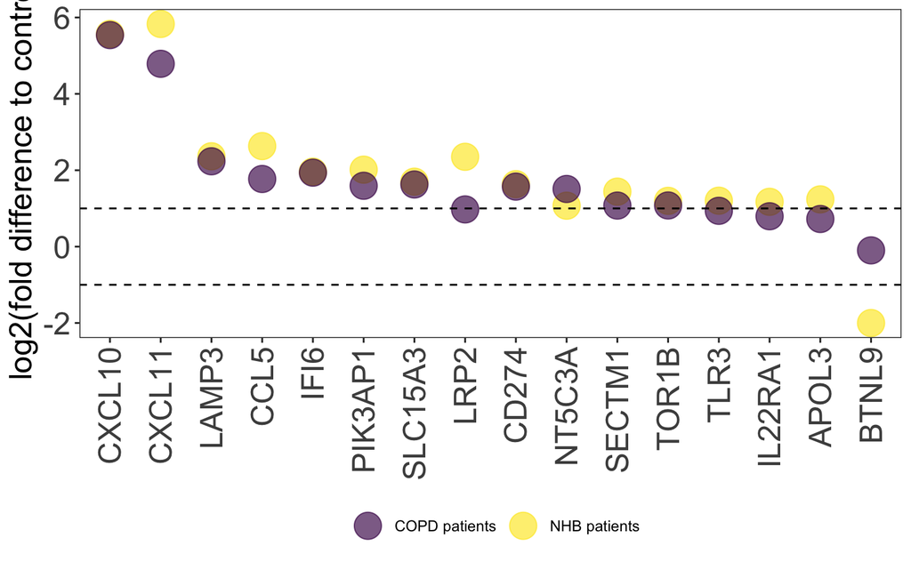